# Data Analysis with R 7: Bioinformatics Visualization

Fred LaPolla

8/4/2024

# Heatmaps

In looking at gene expression data you may want to see a heatmap to see which timepoints/genes are being expressed. A heatmap is a quick way to look at large volumes of data by highlighting cells that have higher or lower values in them.

```r
dolgalevNormRNA <- read.csv("https://raw.githubusercontent.com/fredlapolla/VilcekSummerDataAnalysis2024/main/counts.normalized.csv")
```

# Checking our data

This data provided by Dr. Dolgalev is a table of RNA-seq normalized counts. These are expression values of all genes across different samples. There are wild-type and Tet2-knockout samples (4 of each).

For more details on how the table was generated, the steps are summarized here: http://bit.ly/snsdemo

```r
head(dolgalevNormRNA)
```

```
##            gene pan1wt pan2wt pan3ko pan4ko pan5ko pan6ko pan7wt pan8wt
## 1 0610005C13Rik  0.000  0.000  0.000  0.000  0.000  0.000  0.000  0.000
## 2 0610006L08Rik  0.000  0.000  0.000  0.000  0.000  0.000  0.000  0.000
## 3 0610009B22Rik 35.856 40.314 35.508 37.582 38.570 38.426 41.635 40.510
## 4 0610009E02Rik  1.434  0.000  0.000  0.817  0.000  2.175  0.000  1.870
## 5 0610009L18Rik  2.868  2.573  1.732  3.268  0.000  0.000  0.000  1.246
## 6 0610009O20Rik 74.581 60.041 45.900 44.936 57.855 58.001 47.691 84.759
```

```r
class(dolgalevNormRNA)
```

```
## [1] "data.frame"
```

We can see column 1 is the gene name, column 2, 3 and 8 and 9 are the Wild Type samples, and columns 4:7 are the knock out samples.

# Reordering to group by type

```r
dolgalevNormRNA<- dolgalevNormRNA[c(1:3,8:9, 4:7)]
head(dolgalevNormRNA)
```

```
##            gene pan1wt pan2wt pan7wt pan8wt pan3ko pan4ko pan5ko pan6ko
## 1 0610005C13Rik  0.000  0.000  0.000  0.000  0.000  0.000  0.000  0.000
## 2 0610006L08Rik  0.000  0.000  0.000  0.000  0.000  0.000  0.000  0.000
## 3 0610009B22Rik 35.856 40.314 41.635 40.510 35.508 37.582 38.570 38.426
## 4 0610009E02Rik  1.434  0.000  0.000  1.870  0.000  0.817  0.000  2.175
## 5 0610009L18Rik  2.868  2.573  0.000  1.246  1.732  3.268  0.000  0.000
## 6 0610009O20Rik 74.581 60.041 47.691 84.759 45.900 44.936 57.855 58.001
```

```r
dolgaMat <- as.matrix(dolgalevNormRNA[,2:9], "numeric")
rownames(dolgaMat)<- dolgalevNormRNA[,1]
head(dolgaMat)
```

```
##               pan1wt pan2wt pan7wt pan8wt pan3ko pan4ko pan5ko pan6ko
## 0610005C13Rik  0.000  0.000  0.000  0.000  0.000  0.000  0.000  0.000
## 0610006L08Rik  0.000  0.000  0.000  0.000  0.000  0.000  0.000  0.000
## 0610009B22Rik 35.856 40.314 41.635 40.510 35.508 37.582 38.570 38.426
## 0610009E02Rik  1.434  0.000  0.000  1.870  0.000  0.817  0.000  2.175
## 0610009L18Rik  2.868  2.573  0.000  1.246  1.732  3.268  0.000  0.000
## 0610009O20Rik 74.581 60.041 47.691 84.759 45.900 44.936 57.855 58.001
```

```r
class(dolgaMat)
```

```
## [1] "matrix" "array"
```

```r
class(dolgaMat[,1])
```

```
## [1] "numeric"
```

```r
summary(dolgaMat)
```

```
##      pan1wt             pan2wt             pan7wt             pan8wt
##  Min.   :    0.00   Min.   :    0.00   Min.   :    0.00   Min.   :     0.00
##  1st Qu.:    0.00   1st Qu.:    0.00   1st Qu.:    0.00   1st Qu.:     0.00
##  Median :    0.00   Median :    0.00   Median :    0.00   Median :     0.00
##  Mean   :   96.99   Mean   :  112.84   Mean   :   98.06   Mean   :    82.22
##  3rd Qu.:    2.87   3rd Qu.:    2.57   3rd Qu.:    3.03   3rd Qu.:     3.12
##  Max.   :38552.42   Max.   :83293.70   Max.   :37493.25   Max.   :103143.74
##      pan3ko             pan4ko             pan5ko             pan6ko
##  Min.   :    0.00   Min.   :    0.00   Min.   :    0.00   Min.   :    0.00
##  1st Qu.:    0.00   1st Qu.:    0.00   1st Qu.:    0.00   1st Qu.:    0.00
##  Median :    0.00   Median :    0.00   Median :    0.00   Median :    0.00
##  Mean   :  117.37   Mean   :  112.88   Mean   :  102.06   Mean   :   97.49
##  3rd Qu.:    1.73   3rd Qu.:    2.45   3rd Qu.:    3.21   3rd Qu.:    2.17
##  Max.   :76915.11   Max.   :68016.87   Max.   :54551.21   Max.   :41122.76
```

# Creating a heatmap of KnockOut vs Wild Type

```r
#knockOut <- dolgaMat[,5:8]
#wildType <- dolgaMat[,1:4]

exp_genesAll <- names(which(rowSums(dolgaMat)>15000))

#exp_genesKO <- names(which(rowSums(knockOut)>15000))

#exp_genesWT <- names(which(rowSums(wildType)>15000))

dolgaExp <- dolgaMat[exp_genesAll,]
#expressedKO <- knockOut[exp_genesKO,]
#expressedWT <- wildType[exp_genesWT,]
```

# On Your Own Work

Convert the following data into a matrix, with rownames for the genes being named. Re-order the columns to group WT and KO mice strains together. Make subsets of highly expressed genes (choose your own threshold)

```
## The automatically generated colors map from the 1^st and 99^th of the
## values in the matrix. There are outliers in the matrix whose patterns
## might be hidden by this color mapping. You can manually set the color
## to `col` argument.
##
## Use `suppressMessages()` to turn off this message.
```

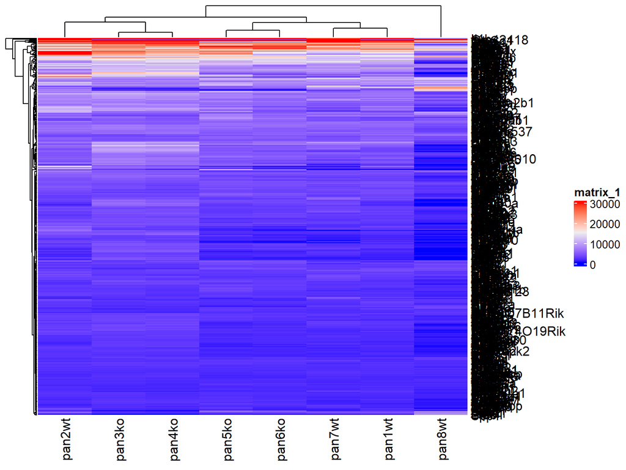

```r
#if (!require("BiocManager", quietly = TRUE))
   # install.packages("BiocManager")

#BiocManager::install("ComplexHeatmap")
library(ComplexHeatmap)
Heatmap(dolgaExp)
```

```r
#Heatmap(expressedKO)
#Heatmap(expressedWT)
```

```
## The automatically generated colors map from the 1^st and 99^th of the
## values in the matrix. There are outliers in the matrix whose patterns
## might be hidden by this color mapping. You can manually set the color
## to `col` argument.
##
## Use `suppressMessages()` to turn off this message.
```

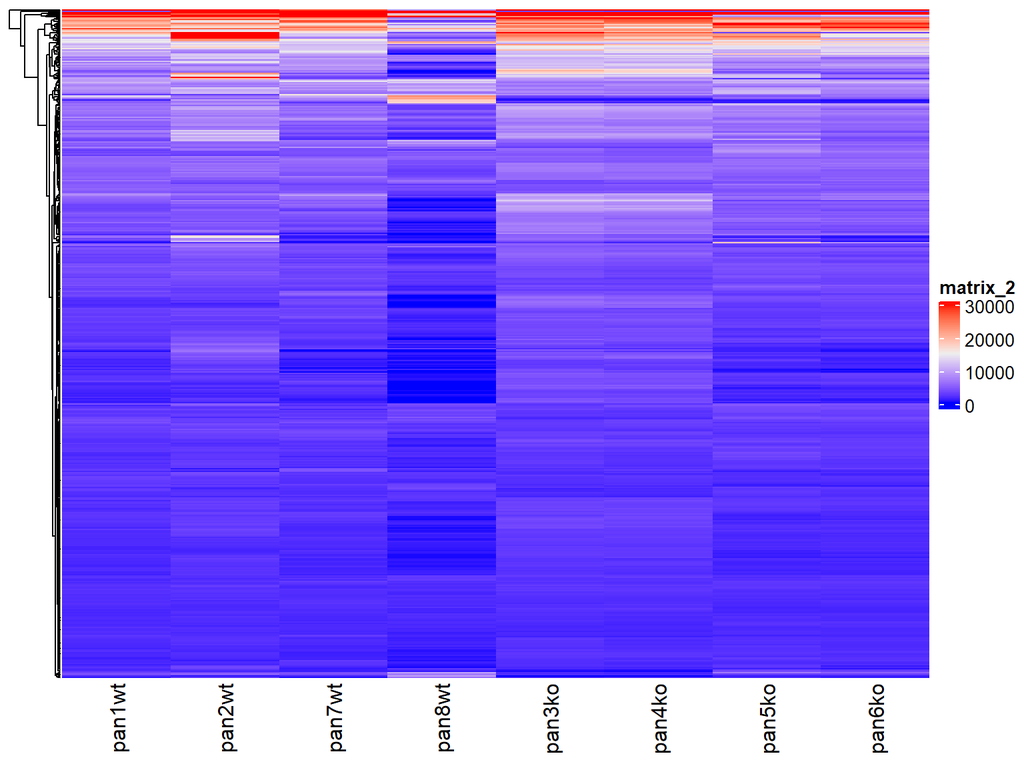

```r
Heatmap(dolgaExp, cluster_columns = FALSE, clustering_method_rows = "complete", show_row_names = FALSE)
```

```r
#Heatmap(expressedKO, cluster_columns = FALSE, clustering_method_rows = "complete", show_row_names = FALSE)
#Heatmap(expressedWT, cluster_columns = FALSE, clustering_method_rows = "complete", show_row_names = FALSE)
```

# On Your Own Work

Try making a heatmap of the data you subsetted in part 1. Try both clustering by column and setting this setting to false. Explore the help information and see what other row clustering methods are available

# Clustering a pairwise correlation of expressions:

We might look at a heatmap of the highly expressed genes. Explore cor() in RStudio, what does this command do? What is t()? Why are we taking the t() of our matrix?

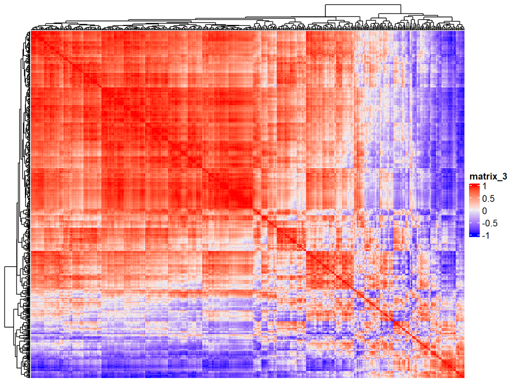

```r
Heatmap(cor(t(dolgaExp)), show_column_names = FALSE, show_row_names = FALSE)
```

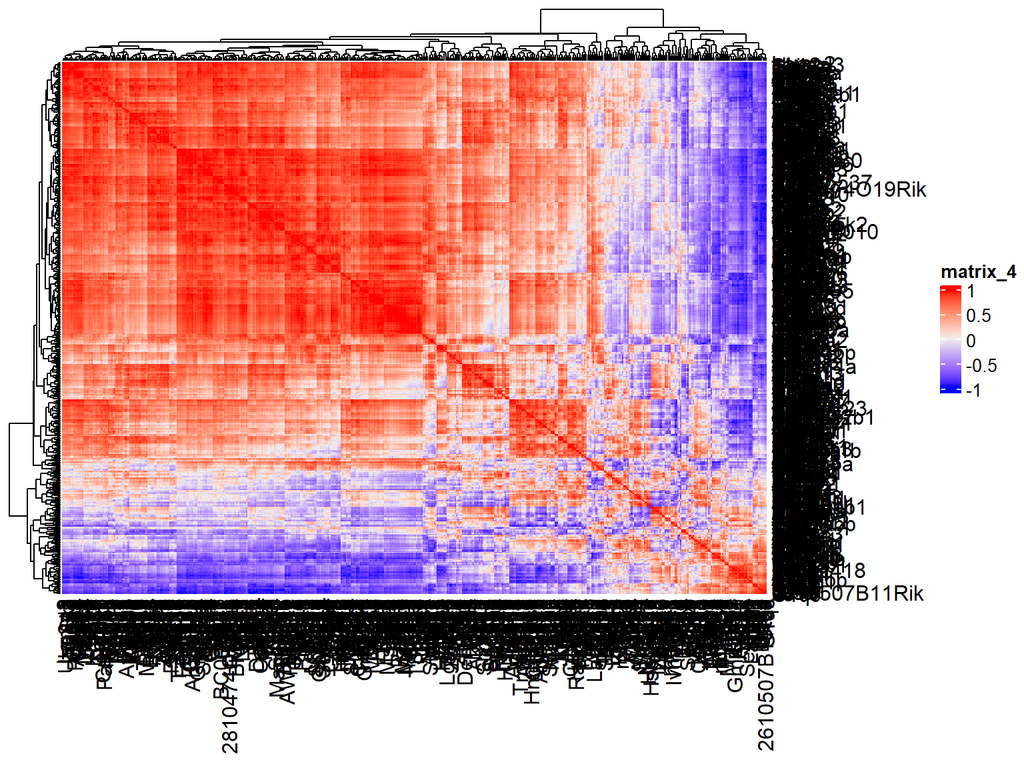

```r
##The following is borrowed from Dr. Itai Yannai

##A correlation of the highly expressed genes in our set
Cormat <- cor(t(dolgaExp))
#then it becomes a heatmap
hotdog <- Heatmap(Cormat)
print(hotdog)
```

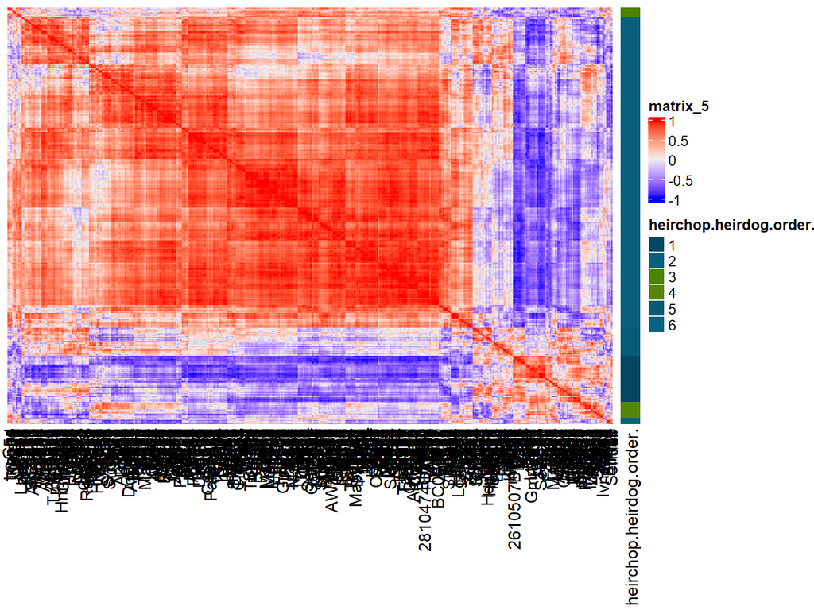

```r
## We cluster the values in this set of gene expression using euclidian distance
## Basically on the backend, R is making a matrix of the values in C and then calculating
##How far they are from one another
heirdog <- hclust(d=dist(Cormat))

## Then we are choosing where to cut the dendrogram, here 6 "branches" or groups have
## been cut, you could also choose to cut the dendrogram by height using h instead of K
heirchop <- as.factor(cutree(heirdog, k=6))
## Now we make a heatmap again using the order of the clustering
hotterdog = ComplexHeatmap::Heatmap(Cormat[heirdog$order, heirdog$order],cluster_rows=FALSE, cluster_columns=FALSE)
## Finally we add annotations to show the groups that we have made
annodog = HeatmapAnnotation(df = data.frame(heirchop[heirdog$order]), which = 'row')
print(hotterdog+annodog)
```

We can also use several methods of hierarchical clustering in our chart. To learn more about these try: ?hclust

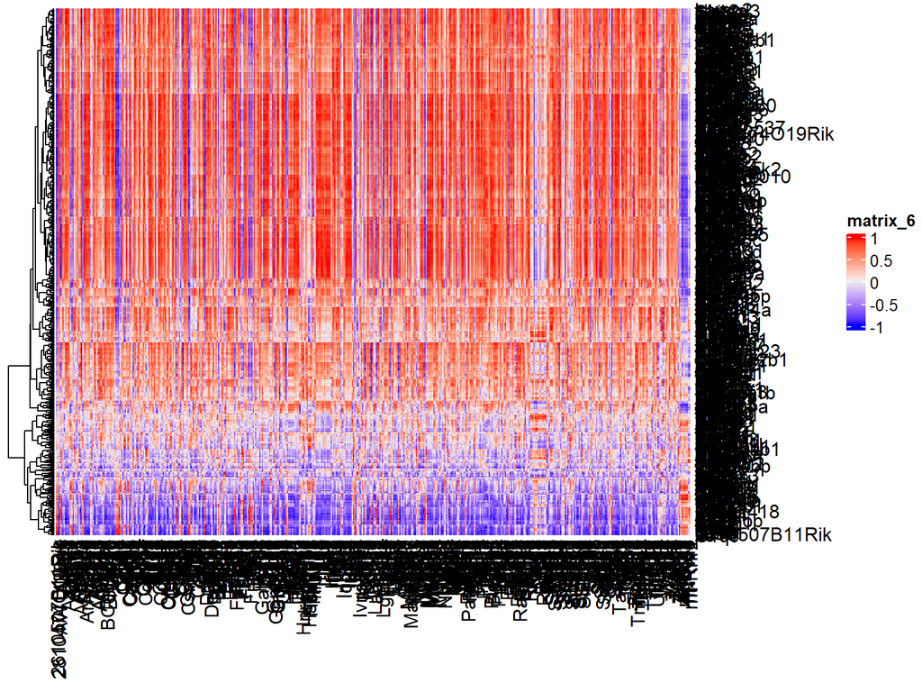

```r
Heatmap(Cormat, clustering_method_rows = "complete", cluster_columns = FALSE )
```

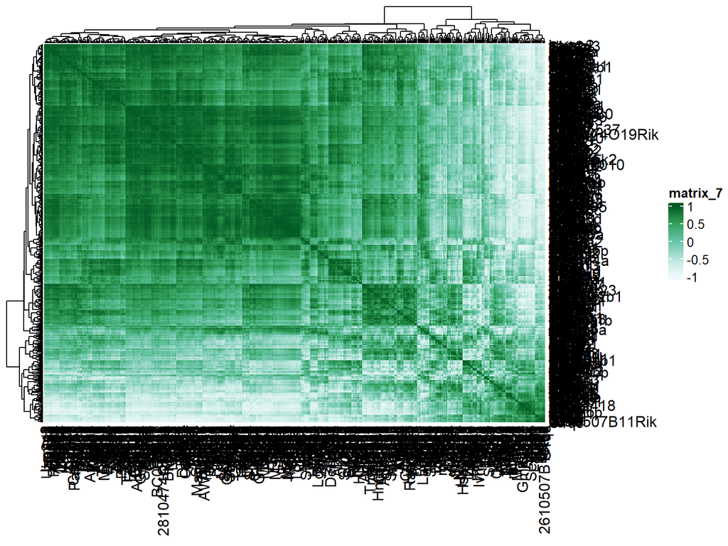

```r
#install.packages("RColorBrewer", repos = "http://cran.us.r-project.org")
library(RColorBrewer)
Heatmap(Cormat, col = brewer.pal(7,"BuGn"))
```

# On Your work

Explore the R Color Brewer Palettes and try a different color palette for a heatmap.

# Unsupervised Clustering

You can also use a command kmeans() for unsupervised clustering:

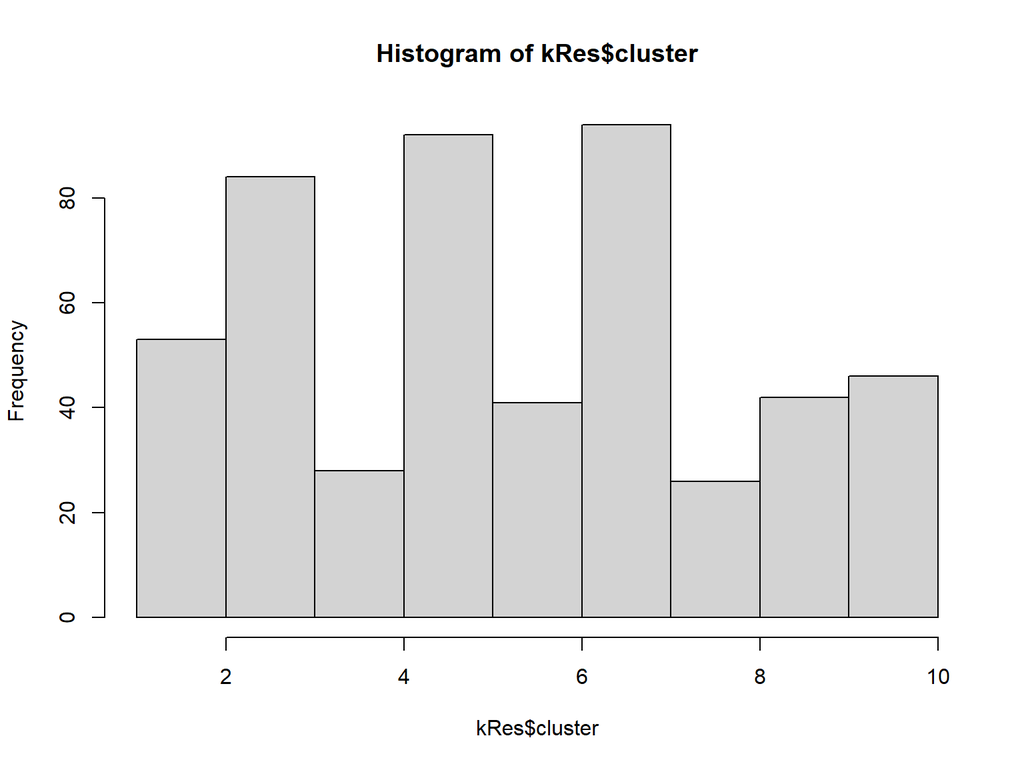

```r
kRes <- kmeans(t(Cormat),  10)
hist(kRes$cluster)
```